# DATA 605 - Final Exam

## 5 points.

Descriptive and Inferential Statistics.

Provide univariate descriptive statistics and appropriate plots for the training data set. Provide a scatterplot matrix for at least **two** of the independent variables and the dependent variable. Derive a correlation matrix for any **three** quantitative variables in the dataset. Test the hypotheses that the correlations between each pairwise set of variables is 0 and provide an 80% confidence interval. Discuss the meaning of your analysis. Would you be worried about familywise error? Why or why not?

**Summary of Train Data**

```r
summary(train)
```

```
##        Id           MSSubClass      MSZoning          LotFrontage
##  Min.   :   1.0   Min.   : 20.0   Length:1460        Min.   : 21.00
##  1st Qu.: 365.8   1st Qu.: 20.0   Class :character   1st Qu.: 59.00
##  Median : 730.5   Median : 50.0   Mode  :character   Median : 69.00
##  Mean   : 730.5   Mean   : 56.9                      Mean   : 70.05
##  3rd Qu.:1095.2   3rd Qu.: 70.0                      3rd Qu.: 80.00
##  Max.   :1460.0   Max.   :190.0                      Max.   :313.00
##                                                      NA's   :259
##     LotArea          Street             Alley             LotShape
##  Min.   :  1300   Length:1460        Length:1460        Length:1460
##  1st Qu.:  7554   Class :character   Class :character   Class :character
##  Median :  9478   Mode  :character   Mode  :character   Mode  :character
##  Mean   : 10517
##  3rd Qu.: 11602
##  Max.   :215245
##
##  LandContour         Utilities          LotConfig
##  Length:1460        Length:1460        Length:1460
##  Class :character   Class :character   Class :character
##  Mode  :character   Mode  :character   Mode  :character
##
##
##
##
##   LandSlope         Neighborhood        Condition1
##  Length:1460        Length:1460        Length:1460
##  Class :character   Class :character   Class :character
##  Mode  :character   Mode  :character   Mode  :character
##
##
##
##
##   Condition2          BldgType          HouseStyle         OverallQual
##  Length:1460        Length:1460        Length:1460        Min.   : 1.000
##  Class :character   Class :character   Class :character   1st Qu.: 5.000
##  Mode  :character   Mode  :character   Mode  :character   Median : 6.000
##                                                           Mean   : 6.099
##                                                           3rd Qu.: 7.000
##                                                           Max.   :10.000
##
```

[output cut: 121 more lines]

```
##  Min.   :    0.00   Min.   : 1.000   Min.   :2006   Length:1460
##  1st Qu.:    0.00   1st Qu.: 5.000   1st Qu.:2007   Class :character
##  Median :    0.00   Median : 6.000   Median :2008   Mode  :character
##  Mean   :   43.49   Mean   : 6.322   Mean   :2008
##  3rd Qu.:    0.00   3rd Qu.: 8.000   3rd Qu.:2009
##  Max.   :15500.00   Max.   :12.000   Max.   :2010
##
##  SaleCondition        SalePrice
##  Length:1460        Min.   : 34900
##  Class :character   1st Qu.:129975
##  Mode  :character   Median :163000
##                     Mean   :180921
##                     3rd Qu.:214000
##                     Max.   :755000
##
```

**Plots of Train Data**

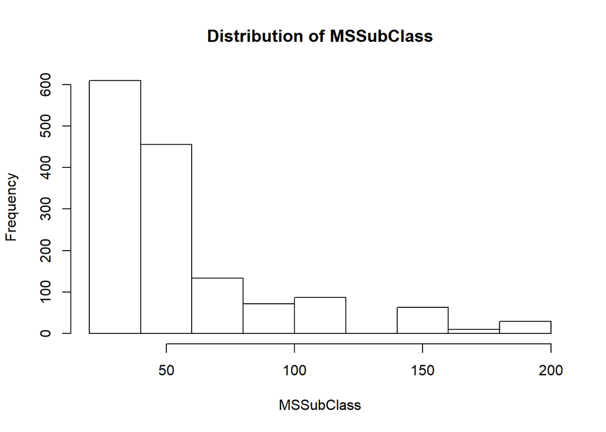

```r
hist(train$MSSubClass, main="Distribution of MSSubClass",xlab="MSSubClass")
```

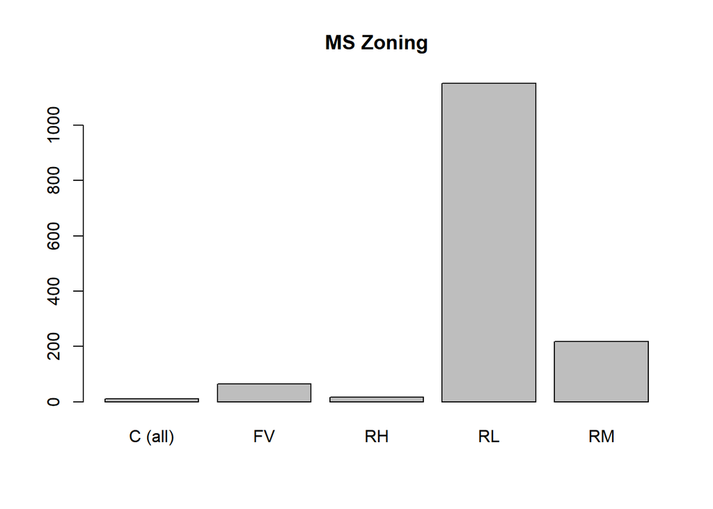

```r
barplot(table(train$MSZoning), main="MS Zoning")
```

RL has the highest frequency , C lowest frequency.

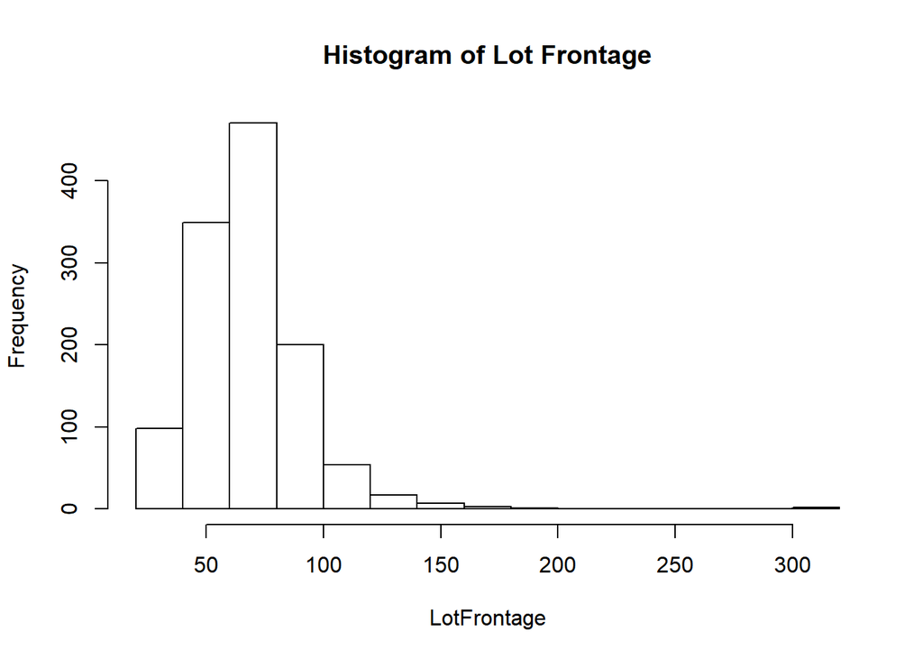

```r
hist(train$LotFrontage,main="Histogram of Lot Frontage",xlab="LotFrontage")
```

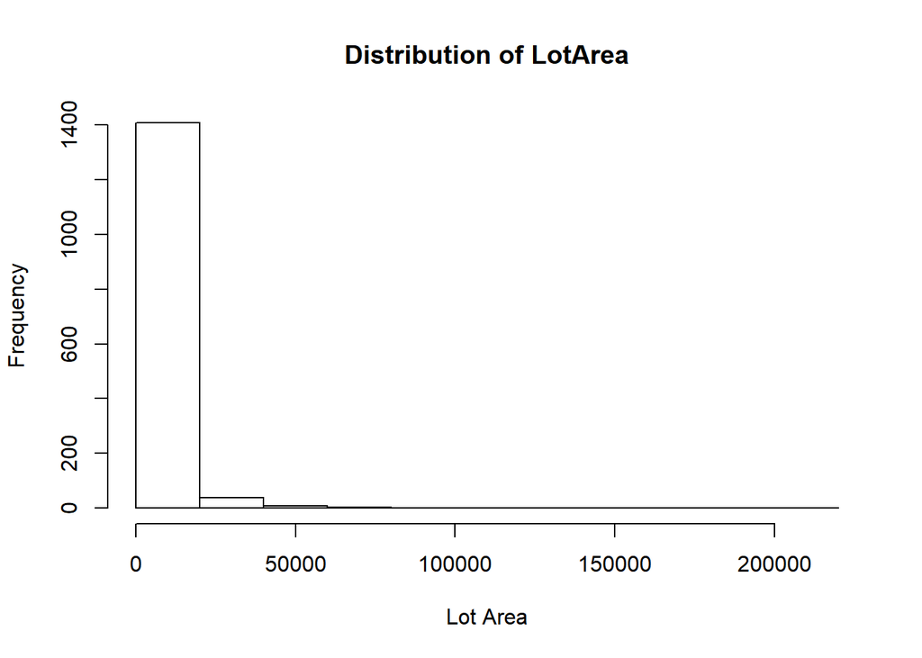

```r
hist(train$LotArea,main="Distribution of LotArea",xlab="Lot Area")
```

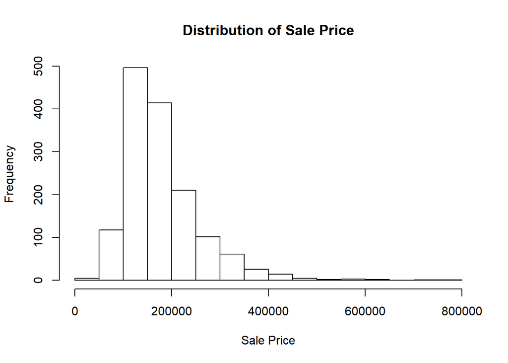

```r
hist(train$SalePrice,main="Distribution of Sale Price",xlab="Sale Price")
```

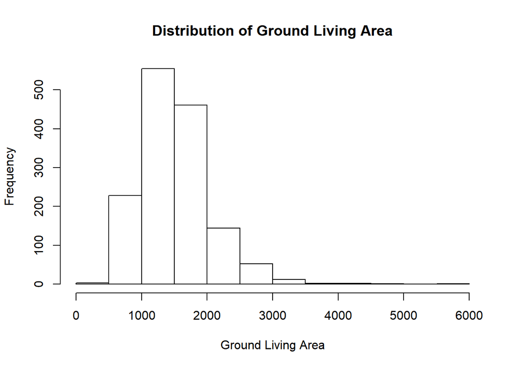

```r
hist(train$GrLivArea,main="Distribution of Ground Living Area",xlab="Ground Living Area")
```

Ground Living Area is approximately normally distributed.

**Since the SalePrice column will be the target variable, we’ll start there and look at how it is distributed.**

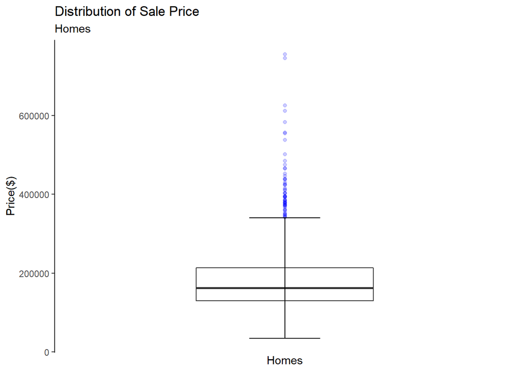

```r
# Plot SalePrice
train %>% ggplot(aes(y=SalePrice)) +
  geom_boxplot(outlier.color="blue", outlier.alpha = 0.2) +
  scale_x_discrete() +
  stat_boxplot(geom ='errorbar',width=.3) +
  labs(title="Distribution of Sale Price",
       subtitle="Homes", y="Price($)",
       x="Homes") + theme_classic()
```

The Plot above displays that the mean price of houses below $200K and they are mostly evenly distributed with some significant outliers above $600K range.

### ScatterPlot

**Scatterplot matrix for “SalePrice”,“GrLivArea”,“LotFrontage”**

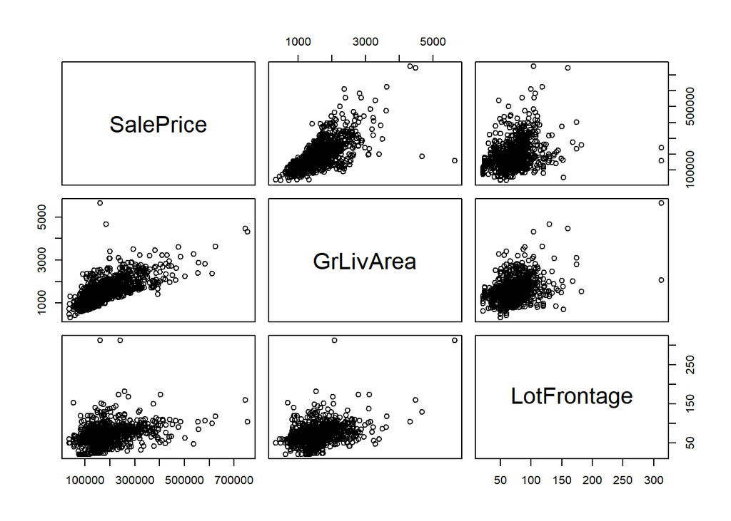

```r
pairs(train[,c("SalePrice","GrLivArea","LotFrontage")])
```

**From the scatter plot we can see that GrLiveArea and LotFrontage are positively correlated with Sale Price.** **Since Most of the sale prices are concentrated between 100k and 300k, while the lot sizes have much less spread.** **The larger lot sizes do not necessarily belong to the most expensive properties, which is why we do not see a stronger correlation.**

### Correlation matrix

```r
cormat <- cor(train[,c("SalePrice","GrLivArea","TotalBsmtSF")])
cormat
```

```
##             SalePrice GrLivArea TotalBsmtSF
## SalePrice   1.0000000 0.7086245   0.6135806
## GrLivArea   0.7086245 1.0000000   0.4548682
## TotalBsmtSF 0.6135806 0.4548682   1.0000000
```

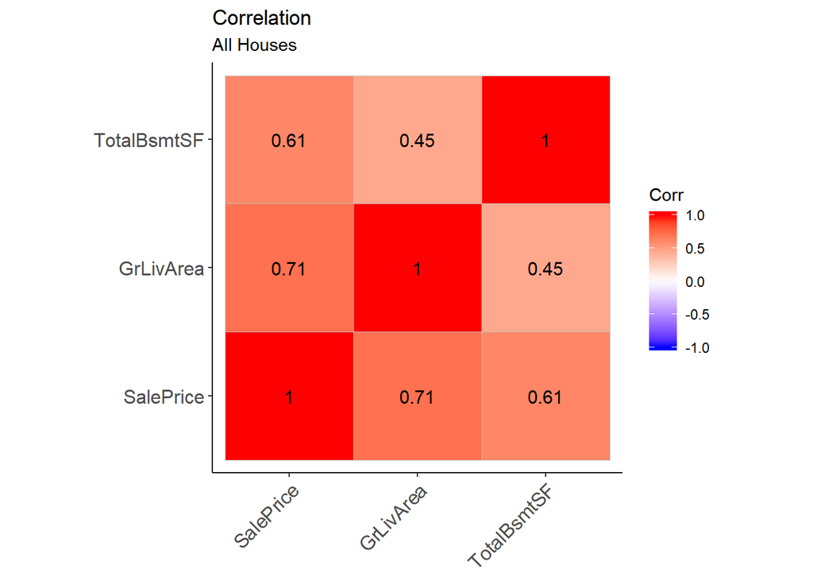

```r
# Subset of variables
train_cor <- train  %>% dplyr::select(SalePrice, GrLivArea, TotalBsmtSF)

# Compute correlations
corr <- cor(train_cor)
ggcorrplot(corr,lab=TRUE, ggtheme = ggplot2::theme_classic) +
  labs(title="Correlation",subtitle="All Houses")
```

**The graph above displays that Sale Price shows strong positive correlation with “GrLivArea”" and moderate correlation with TotalBsmTSF.** **In Addition,“GrLivArea”" shows Strong positive correlation with SalePrice and weak positive correlation with “TotalBsmSF” and also** **“TotalBsmSF”" shows moderate positive correlation with SalePrice and weak positive correlation with “GrLivArea”.**

### Hypothesis and 80% confidence interval

Test the hypotheses that the correlations between each pairwise set of variables is 0 and provide an 80% confidence interval.Discuss the meaning of your analysis. Would you be worried about familywise error? Why or why not?

Null (Ho) Hypothesis: The correlation between GrLivArea and SalePrice is 0 Alternative(H1) Hypothesis: The correlation between GrLivArea and SalePrice is other than 0

```r
cor.test(train$GrLivArea, train$TotalBsmtSF, conf.level = 0.8)
```

```
##
##  Pearson's product-moment correlation
##
## data:  train$GrLivArea and train$TotalBsmtSF
## t = 19.503, df = 1458, p-value < 0.00000000000000022
## alternative hypothesis: true correlation is not equal to 0
## 80 percent confidence interval:
##  0.4278380 0.4810855
## sample estimates:
##       cor
## 0.4548682
```

Since the the p value of the test is less than 0.05 at 5% level of significance we reject the null hypothesis and conclude that the correlation between **GrLivArea** and **TotalBsmtSF** is other than 0.

```r
cor.test(train$SalePrice, train$TotalBsmtSF, conf.level = 0.8)
```

```
##
##  Pearson's product-moment correlation
##
## data:  train$SalePrice and train$TotalBsmtSF
## t = 29.671, df = 1458, p-value < 0.00000000000000022
## alternative hypothesis: true correlation is not equal to 0
## 80 percent confidence interval:
##  0.5922142 0.6340846
## sample estimates:
##       cor
## 0.6135806
```

Since the the p value of the test is less than 0.05 at 5% level of significance we reject the null hypothesis and conclude that the correlation between **SalePrice** and **TotalBsmtSF** is other than 0.

80 percent confidence interval of the test is 0.5922142 0.6340846

```r
cor.test(train$SalePrice, train$GrLivArea, conf.level = 0.8)
```

```
##
##  Pearson's product-moment correlation
##
## data:  train$SalePrice and train$GrLivArea
## t = 38.348, df = 1458, p-value < 0.00000000000000022
## alternative hypothesis: true correlation is not equal to 0
## 80 percent confidence interval:
##  0.6915087 0.7249450
## sample estimates:
##       cor
## 0.7086245
```

Since the the p value of the test is less than 0.05 at 5% level of significance we reject the null hypothesis and conclude that the correlation between **SalePrice** and **GrLivArea** is other than 0.

80 percent confidence interval of the test is 0.6915087 0.7249450

### Familywise Error

type I error is the rejection of a true null hypothesis (also known as a “false positive” finding or conclusion)

```r
FWE <- 1 - (1 - .05)^2
FWE
```

```
## [1] 0.0975
```

There is a 9.75% chance of type 1 error. Since the chance is low I will not be worried for family wise error .

## 5 points.

Linear Algebra and Correlation.

Invert your correlation matrix from above. (This is known as the precision matrix and contains variance inflation factors on the diagonal.) Multiply the correlation matrix by the precision matrix, and then multiply the precision matrix by the correlation matrix. Conduct LU decomposition on the matrix.

Invert your correlation matrix.This is known as the precision matrix and contains variance inflation factors on the diagonal.

```r
# find inverse
precision_mat <- solve(cormat)
```

Multiply the correlation matrix by the precision matrix, and then multiply the precision matrix by the correlation matrix.

```r
# Multiply the correlation matrix by the precision matrix
cor_prec <- cormat %*% precision_mat
cor_prec
```

```
##                             SalePrice                  GrLivArea
## SalePrice   1.00000000000000022204460 -0.00000000000000002081668
## GrLivArea   0.00000000000000005551115  1.00000000000000000000000
## TotalBsmtSF 0.00000000000000000000000  0.00000000000000005551115
##                          TotalBsmtSF
## SalePrice   0.0000000000000000000000
## GrLivArea   0.0000000000000001110223
## TotalBsmtSF 1.0000000000000000000000
```

```r
#  multiply the precision matrix by the correlation matrix
prec_cor <-   precision_mat %*% cormat
prec_cor
```

```
##                            SalePrice                 GrLivArea
## SalePrice   0.9999999999999997779554 -0.0000000000000001665335
## GrLivArea   0.0000000000000002012279  1.0000000000000004440892
## TotalBsmtSF 0.0000000000000000000000  0.0000000000000001110223
##                           TotalBsmtSF
## SalePrice   -0.0000000000000001110223
## GrLivArea    0.0000000000000001665335
## TotalBsmtSF  1.0000000000000000000000
```

```r
# LU Decomposistion
library(pracma)
lu(cormat)
```

```
## $L
##             SalePrice  GrLivArea TotalBsmtSF
## SalePrice   1.0000000 0.00000000           0
## GrLivArea   0.7086245 1.00000000           0
## TotalBsmtSF 0.6135806 0.04031325           1
##
## $U
##             SalePrice GrLivArea TotalBsmtSF
## SalePrice           1 0.7086245   0.6135806
## GrLivArea           0 0.4978513   0.0200700
## TotalBsmtSF         0 0.0000000   0.6227098
```